# The Role of Personal Entry Characteristics in Dropout from Teacher Education

Doctoral Colloquium, 21 February 2024

Author

David Simon

Published

14 February 2024

## Brief Introduction and Research Questions

Despite growing interest in dropout research, limited attention has been given to the context of teacher education. We utilized a Latent-Class-Analysis to investigate dropout, as this allows us to map subgroups of students based on their individual characteristics prior to entering teacher education. In doing so we are able to take multiple characteristics and their interactions into account at the same time.

Evidence from general dropout research regularly highlights the relevance of individual characteristics prior to entering higher education, such as socioeconomic, familiar and educational background, personality or motivation for choosing a study subject. We are interested in the question which combination of prerequisites makes people disadvantaged by the conditions at higher education institutions. Our assumption is, that some groups of students do not succeed in integrating into the social or academic domain of higher education institutions and that, as a result, they will not be able to make productive use of the learning opportunities available and therefore be more likely to drop out of teacher education.

This concept is derived from the Student Integration Model (Tinto, 1975), one of the more influential theories aiming to explain dropout. It distinguishes between the social and academic integration of students and assumes that those who are not sufficiently integrated into the corresponding social and academic domain within higher education institutions decide to drop out. Academic integration encompasses academic performance as proof of formal affiliation as well as an adjustment to the norms held by higher education institutions themselves (e.g. achievement orientation). Social integration refers to the establishment of contacts with faculty and students, providing support and cognitive stimulation. Both types of integration are seen to foster goal and institutional commitment, which we think will be reflected in an increased engagement and an increased utilization of learning opportunities available.

Consequently, we aim to answer three research questions:

*Research Question 1:* How many statistically distinct subgroups, regarding the entry characteristics of first-year teacher students, are there and can at least one of them be theoretically described as a risk group equaling an accumulation of unfavorable prerequisites in regards to educational failure?

*Research Question 2:* Do members of this group (these groups) show higher dropout rates compared to their peers?

*Research Question 3:* Can this relationship between risk group(s) and dropout from teacher education be explained through a failure of integration into the social or academic domain of higher education institutions and the subsequent unproductive utilization of learning opportunities?

This document is concerned with the first step of data analysis, the Latent-Class-Analysis, in order to address Research Question 1. If you are interested in the whole proposal you can have a look at the preregistration here: https://doi.org/10.17605/OSF.IO/D2K7Y.

I would like to ask you to read the following document. We had to make a number of decisions and I am interested in whether you find the approach convincing or not. The topics of interest are listed at the end of the document (section Questions).

## Data Analysis

### Variable Selection

Several determinants that define the dropout process within a general population of students prior to entering a study program have been distinguished (Heublein, 2014). Disadvantages are to be expected in the case of lower socioeconomic status, migration background, non-Gymnasium entrance certificate, lower prior academic achievements, a completion of a vocational training prior to entering higher education, lower scores on the personality trait conscientiousness and a primarily extrinsic motivation for choosing a degree program (Isleib et al., 2019). The set of entry characteristics discussed in this strand of research served us as a set of indicators for the Latent-Class-Analysis:

[output not shown]

### Data Base

Our analyses are based on data from the German Panel of Teacher Education as part of the Starting Cohort First-Year Students (SC5) of the National Educational Panel Study (NEPS) (Blossfeld & Roßbach, 2019).The NEPS initially included about 18000 first-year students in the winter term 2010/2011 and an oversampling of teacher education students (about 5500 students). From 2014 onwards, multiple survey instruments, for example, aspects of professional competence, instructional practices or professional development, were specifically addressed to teachers. The data was collected in 19 waves until 2022 (Schaeper, 2023) .

```r
library(haven)          # to import SPSS files
library(tidyverse)      # for data management
library(reshape)
library(reshape2)
library(rquery)         # to copy STATA merge behavior
library(rqdatatable)
library(fauxnaif)       # for defining missing values
                          # (remotes::install_github("rossellhayes/fauxnaif")
library(psych)          # for scale construction
library(poLCA)          # for LCA
library(MASS)
library(tidySEM)
library(scatterplot3d)
library(LCAplotter)     # library(devtools)
                          # devtools::install_github("DavidykZhao/LCA_plotter")
library(report)         # for producing reports
library(lavaan)         # for SEM
library(ggpubr)         # for arranging plots


#### ----------------- (1) Read Data and Data Management ----------------- ####

# Cohort Profile as a starting point

cohort <- haven::read_sav("Data_SC5_D_18-0-0/SC5_CohortProfile_D_18-0-0.sav") %>%
          dplyr::select(ID_t, wave, cohort,
                                    tx80121,      # oversample of tea edu (= 1)
                                    tx80107) %>%  # first participation in wave
          dplyr::filter(wave == 1)


# Filter measures from CATI:

cati_w1 <- haven::read_sav("Data_SC5_D_18-0-0/SC5_pTargetCATI_D_18-0-0.sav") %>%
           dplyr::select(ID_t, wave, tg02001_ha,  # intended degree
                                     tg24150_g1,  # foreign student (!= 3)
                                     t731301_g1,  # parental education
                                     t731351_g1,
                                     t731403_g8,  # parental occupation
                                     t731453_g8,
                                     t405060_g1,  # migration background
                                     t405090_g1,
                                     t70000m, t70000y, # date of birth
                                     t700001) %>% # gender
           dplyr::filter(wave == 1)

cati_b5 <- haven::read_sav("Data_SC5_D_18-0-0/SC5_pTargetCATI_D_18-0-0.sav") %>%
           dplyr::select(ID_t, wave, t66800a, t66800f,           # extra
                                     t66800b, t66800g, t66800k,  # agree
                                     t66800c, t66800h,           # consc
                                     t66800d, t66800i,           # neuro
                                     t66800e, t66800j) %>%       # opene
          dplyr::filter(wave == 3)

cati_b5_w10 <- haven::read_sav("Data_SC5_D_18-0-0/SC5_pTargetCATI_D_18-0-0.sav") %>%
               dplyr::select(ID_t, wave, t66800a, t66800f,
                                         t66800b, t66800g, t66800k,
                                         t66800c, t66800h,
                                         t66800d, t66800i,
                                         t66800e, t66800j) %>%
               dplyr::filter(wave == 10)

cati_do1 <- haven::read_sav("Data_SC5_D_18-0-0/SC5_pTargetCATI_D_18-0-0.sav") %>%
            dplyr::select(ID_t, wave, tg60031) %>%
            dplyr::filter(wave == 10)


cati_doi <- haven::read_sav("Data_SC5_D_18-0-0/SC5_pTargetCATI_D_18-0-0.sav") %>%
            dplyr::select(ID_t, wave, tg64051) %>%
            dplyr::filter(wave == 9)


# Filter measures from CAWI:

cati_do2 <- haven::read_sav("Data_SC5_D_18-0-0/SC5_pTargetCAWI_D_18-0-0.sav") %>%
            dplyr::select(ID_t, wave, tg60021) %>%
            dplyr::filter(wave == 11)

cawi_w8 <- haven::read_sav("Data_SC5_D_18-0-0/SC5_pTargetCAWI_D_18-0-0.sav") %>%
           dplyr::select(ID_t, wave, tg61031, tg61032, tg61033,  # int mo
                                     tg61061, tg61062, tg61063,
                                     tg61041, tg61042, tg61043,
                                     tg61021, tg61022, tg61023,  # ext mo
                                     tg61011, tg61012, tg61013,
                                     tg61071, tg61072, tg61073,
                                     tg61051, tg61052, tg61053) %>%
           dplyr::filter(wave == 8)

cawi_sp1 <- haven::read_sav("Data_SC5_D_18-0-0/SC5_pTargetCAWI_D_18-0-0.sav") %>%
            dplyr::select(ID_t, wave, tg53232, tg53234, tg53236,  # ac int
                                      tg53231, tg53233, tg53235,
                                      tg53211, tg53212, tg53213,
                                      tg53111, tg53112, tg53112,  # so int
                                      tg53121, tg53122, tg53123,
                                      t241011, t241012, t241013,  # for lo
                                      t246411, t246412, t246413) %>%
                                      # practice orientation
            dplyr::filter(wave == 2)

cawi_sp2 <- haven::read_sav("Data_SC5_D_18-0-0/SC5_pTargetCAWI_D_18-0-0.sav") %>%
            dplyr::select(ID_t, wave, t261843, t261845, t261846) %>%  # infor lo
            dplyr::filter(wave == 4)


# Filter measures from spSchool:

spsch <- haven::read_sav("Data_SC5_D_18-0-0/SC5_spSchool_D_18-0-0.sav") %>%
         dplyr::select(ID_t, wave, spell, subspell, ts11204,       # school
                                                    ts11209,       # certificate
                                                    ts11218) %>%   # GPA
         dplyr::filter(subspell == 0)  %>%  # keep full / harmonized episodes
         dplyr::group_by(ID_t) %>% dplyr::slice_max(order_by = spell,
                                                    with_ties = T) %>%
                                   dplyr::slice_tail(n = 1)  # keep highest spell


# Filter measures from spVocTrain:

spvoc_pr <- haven::read_sav("Data_SC5_D_18-0-0/SC5_spVocTrain_D_18-0-0.sav") %>%
            dplyr::select(ID_t, wave, spell, subspell, tx20100,  # linkage
                                                       ts15201,  # type of voc
                                                       ts1512m,  # end year voc
                                                       ts1512y,  # end month voc
                                                       ts15218) %>%  # finished
           dplyr::filter(subspell == 0 & tx20100 == 1
                         & ts15201 <= 4
                         & ts1512y <= 2010 & ts1512m <= 10) %>%
           # keep full / harmonized episodes & completion before WT 2010
           dplyr::group_by(ID_t) %>%
           dplyr::summarise(ts15218 = case_when(any(ts15218 == 1) ~ 3,
                                                any(ts15218 == 2)
                                                & any(is.na(ts15218)) ~ as.numeric(NA),
                                                all(ts15218 == 2) ~ 4))
           # summarize the data per person across spells
           # 3 = yes, 4 = no
```

```r
spvoc <- haven::read_sav("Data_SC5_D_18-0-0/SC5_spVocTrain_D_18-0-0.sav") %>%
         dplyr::select(ID_t, wave, spell, subspell,
                       h_aktstu,        # 1st study episode WT 2010
                       tg24202_g1,      # type of intended teaching degree
                       tg24170_g5,      # subject group
                       tg01003_ha) %>%  # Type of higher education inst
         dplyr::filter(wave == 1) %>%
         dplyr::filter(h_aktstu == 1) %>%
         dplyr::group_by(ID_t) %>% dplyr::slice_max(order_by = spell,
                                                    with_ties = T) %>%
         dplyr::slice_tail(n = 1)


####  -------------------------- (2) Merge Data -------------------------- ####

data <- rquery::natural_join(cohort, cati_w1,
                             by = "ID_t",
                             jointype = "LEFT")

data <- rquery::natural_join(data, cati_b5,
                             by = "ID_t",
                             jointype = "LEFT")

data <- rquery::natural_join(data, cati_b5_w10,  # supply Big 5
                             by = "ID_t",        # with answers from wave 10
                             jointype = "LEFT")

data <- rquery::natural_join(data, cawi_w8,
                             by = "ID_t",
                             jointype = "LEFT")

data <- rquery::natural_join(data, cawi_sp1,
                             by = "ID_t",
                             jointype = "LEFT")

data <- rquery::natural_join(data, cawi_sp2,
                             by = "ID_t",
                             jointype = "LEFT")

data <- rquery::natural_join(data, cati_do1,
                             by = "ID_t",
                             jointype = "LEFT")

data <- rquery::natural_join(data, cati_doi,
                             by = "ID_t",
                             jointype = "LEFT")

data <- rquery::natural_join(data, cati_do2,
                             by = "ID_t",
                             jointype = "LEFT")

data <- rquery::natural_join(data, spsch,
                             by = "ID_t",
                             jointype = "LEFT")

data <- rquery::natural_join(data, spvoc_pr,
                             by = "ID_t",
                             jointype = "LEFT")

data <- rquery::natural_join(data, spvoc,
                             by = "ID_t",
                             jointype = "LEFT") %>%

                             # dplyr::filter(tx80121 == 1) %>%
                             # oversample of tea edu
                             dplyr::filter(tg02001_ha <= 7) %>%
                             # intended degree = teacher education (wave 1)
                             dplyr::filter(tg24150_g1 != 3) %>%
                             # exclude foreign students
                             dplyr::filter(h_aktstu == 1) %>%
                             # only start of studies WT 2010
                             dplyr::filter(tx80107 == 1) %>%
                             # only first participation in wave 1
                             dplyr::select(-wave) %>%
                             # drop wave, contains no information anymore

                             dplyr::mutate(across(everything(),
                                                  ~ fauxnaif::na_if_in(., ~ . < 0)))
                             # replace all negative Values with NA

####  ------------ (3) Compute Scale Scores and New Variables ------------ ####

## entry characteristics

# SES: Parental education (par_edu), parental occupation (par_ocu)
data2 <- data %>%
  dplyr::mutate(par_edu = case_when((t731301_g1 < 9 & t731351_g1 < 9) ~ 1,
                                    (t731301_g1 >= 9 & t731351_g1 >= 9) ~ 3,
                                    (t731301_g1 >= 9 | t731351_g1 >= 9) ~ 2,
                                    TRUE ~ as.numeric(NA))) %>%
                                    # 1 = no parent tertiary education, 2 = one
                                    # parent, 3 = both parents

  dplyr::mutate(par_ocu = case_when((t731403_g8 >= 9 & t731453_g8 >= 9) |
                                    (t731403_g8 == 4 & t731453_g8 == 4) ~ 1,
                                    # (t731403_g8 %in% c(1:3, 5:8) |
                                    # t731453_g8 %in% c(1:3, 5:8)) ~ 2,
                                    (t731403_g8 <= 2 | t731453_g8 <= 2) ~ 3,
                                    (t731403_g8 %in% c(3, 5:8) |
                                     t731453_g8 %in% c(3, 5:8)) ~ 2,
                                    TRUE ~ as.numeric(NA)))
                                    # 1 = working class,
                                    # 2 = intermediate class
                                    # 3 = upper class

# migration background
data3 <- data2 %>%
  dplyr::mutate(mig_bac = case_when((t405060_g1 <= 2 & t405090_g1 <= 2) ~ 1,
                                    (t405060_g1 == 3 | t405090_g1 == 3) ~ 2,
                                    TRUE ~ as.numeric(NA)))
                                    # 1 = both parents born in Germany,
                                    # 2 = at least one abroad

data4 <- data3 %>%
  dplyr::mutate(typ_sch = case_when(ts11204 != 8 ~ 1,
                                    ts11204 == 8 ~ 2,
                                    TRUE ~ as.numeric(NA)))  %>%
                                    # 1 = non-Gymnasium,
                                    # 2 = Gymnasium (also Kolleg)

  dplyr::mutate(paa_gpa = case_when(ts11218 >= 3.6 & ts11218 <= 4.0 ~ 1,
                                    ts11218 >= 2.6 & ts11218 < 3.6 ~ 2,
                                    ts11218 >= 1.6 & ts11218 < 2.6 ~ 3,
                                    ts11218 >= 1.0 & ts11218 < 1.6 ~ 4,
                                    TRUE ~ as.numeric(NA)))  %>%
                                    # 1 = sufficient, 2 = satisfactory,
                                    # 3 = good, 4 = very good)

  dplyr::mutate(voc_tra = case_when(ts15218 == 4 ~ 1,
                                    ts15218 == 3 ~ 2,
                                    TRUE ~ as.numeric(NA)))
                                    # 1 = no, 2 = yes
```

```r
# individual characteristics
# (big 5, motivation for choosing teacher education (femola))

# scales
data5 <- data4 %>%
  dplyr::mutate(big_ext = rowMeans(subset(data4, select = c(t66800a, t66800f)),
                                   na.rm = TRUE))  %>%
  dplyr::mutate(big_agr = rowMeans(subset(data4, select = c(t66800b, t66800g,
                                                            t66800k)),
                                   na.rm = TRUE))  %>%
  dplyr::mutate(big_con = rowMeans(subset(data4, select = c(t66800c, t66800h)),
                                   na.rm = TRUE))  %>%
  dplyr::mutate(big_neu = rowMeans(subset(data4, select = c(t66800d, t66800i)),
                                   na.rm = TRUE))  %>%
  dplyr::mutate(big_ope = rowMeans(subset(data4, select = c(t66800e, t66800j)),
                                   na.rm = TRUE))  %>%
  dplyr::mutate(fem_edi = rowMeans(subset(data4, select = c(tg61031, tg61032,
                                                            tg61033)),
                                   na.rm = TRUE))  %>%
  dplyr::mutate(fem_ssi = rowMeans(subset(data4, select = c(tg61061, tg61062,
                                                            tg61063)),
                                   na.rm = TRUE))  %>%
  dplyr::mutate(fem_abe = rowMeans(subset(data4, select = c(tg61041, tg61042,
                                                            tg61043)),
                                   na.rm = TRUE))  %>%
  dplyr::mutate(fem_tff = rowMeans(subset(data4, select = c(tg61021, tg61022,
                                                            tg61023)),
                                   na.rm = TRUE))  %>%
  dplyr::mutate(fem_fis = rowMeans(subset(data4, select = c(tg61011, tg61012,
                                                            tg61013)),
                                   na.rm = TRUE))  %>%
  dplyr::mutate(fem_lod = rowMeans(subset(data4, select = c(tg61071, tg61072,
                                                            tg61073)),
                                   na.rm = TRUE))  %>%
  dplyr::mutate(fem_soi = rowMeans(subset(data4, select = c(tg61051, tg61052,
                                                            tg61053)),
                                   na.rm = TRUE)) %>%

  dplyr::mutate(fem_inm = rowMeans(subset(data4, select = c(tg61031, tg61032,
                                                            tg61033, tg61061,
                                                            tg61062, tg61063,
                                                            tg61041, tg61042,
                                                            tg61043)),
                                   na.rm = TRUE)) %>%

  dplyr::mutate(fem_exm = rowMeans(subset(data4, select = c(tg61021, tg61022,
                                                            tg61023, tg61011,
                                                            tg61012, tg61013,
                                                            tg61071, tg61072,
                                                            tg61073, tg61051,
                                                            tg61052, tg61053)),
                                   na.rm = TRUE))
```

The resulting sample comprises **5775 first-year teacher students** (*M* = 20.73 years, *SD* = 2.87 years, 4337 women).

### Examination of the Observed Data

While describing the data numerically, see table below, it is noticeable that the hypothetically continuous variables (Big 5 and motivation for choosing teacher education) do have just a few unique values and some response categories have near-zero frequencies. It is recommended that continuous variables should have “many” unique values and, if not, it is advised to better model them as ordinal (Van Lissa et al., 2023).

```r
data6 <- data5 %>%
  dplyr::mutate(across(everything(), ~ ifelse(is.nan(.x), NA, .x)))

round_df <- function(df, digits) {
  nums <- vapply(df, is.numeric, FUN.VALUE = logical(1))
  df[,nums] <- round(df[,nums], digits = digits)
  (df)
}

# examine variables
df <- data6 %>%
  dplyr::select(par_edu,
                par_ocu,
                mig_bac,
                typ_sch,
                paa_gpa,
                big_ext,
                big_agr,
                big_con,
                big_neu,
                big_ope,
                fem_inm,
                fem_exm) %>%
  dplyr::rename(parental_education = par_edu) %>%
  dplyr::rename(parental_occupation = par_ocu) %>%
  dplyr::rename(migration_background = mig_bac) %>%
  dplyr::rename(type_of_school = typ_sch) %>%
  dplyr::rename(prior_academic_achievement = paa_gpa) %>%
  dplyr::rename(extraversion = big_ext) %>%
  dplyr::rename(agreeableness = big_agr) %>%
  dplyr::rename(conscientiousness = big_con) %>%
  dplyr::rename(neuroticism = big_neu) %>%
  dplyr::rename(openness = big_ope) %>%
  dplyr::rename(intrinsic_motivation = fem_inm) %>%
  dplyr::rename(extrinsic_motivation = fem_exm)

desc <- tidySEM::descriptives(df)
desc <- desc[, c("name", "type", "n", "missing", "unique", "mode")]
desc <- round_df(desc, digits = 2)
desc
```

```
                         name    type    n missing unique mode
1          parental_education numeric 5668    0.02      3 1.00
2         parental_occupation numeric 4749    0.18      3 3.00
3        migration_background numeric 5707    0.01      2 1.00
4              type_of_school numeric 5757    0.00      2 2.00
5  prior_academic_achievement numeric 5708    0.01      4 3.00
6                extraversion numeric 4763    0.18      9 3.00
7               agreeableness numeric 4763    0.18     11 3.67
8           conscientiousness numeric 4763    0.18      8 3.50
9                 neuroticism numeric 4763    0.18      9 3.00
10                   openness numeric 4763    0.18      9 3.00
11       intrinsic_motivation numeric 2341    0.59     44 3.22
12       extrinsic_motivation numeric 2341    0.59     54 2.25
```

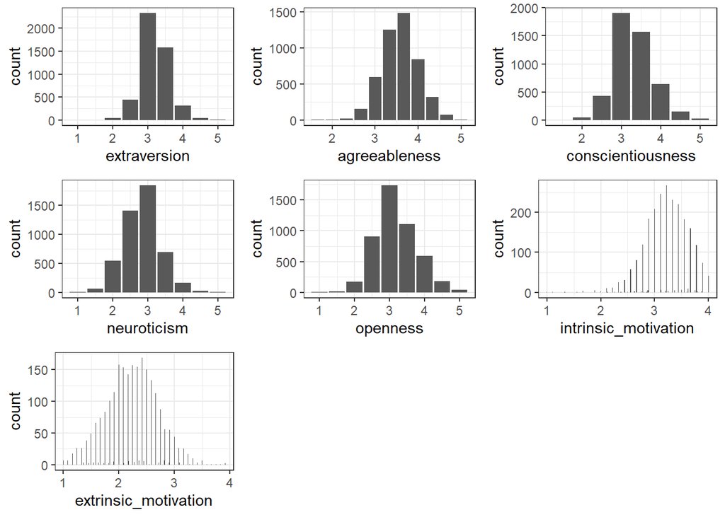

```r
desc_plot <- data6 %>%
  dplyr::select(big_ext,
                big_agr,
                big_con,
                big_neu,
                big_ope,
                fem_inm,
                fem_exm) %>%
  dplyr::rename(extraversion = big_ext) %>%
  dplyr::rename(agreeableness = big_agr) %>%
  dplyr::rename(conscientiousness = big_con) %>%
  dplyr::rename(neuroticism = big_neu) %>%
  dplyr::rename(openness = big_ope) %>%
  dplyr::rename(intrinsic_motivation = fem_inm) %>%
  dplyr::rename(extrinsic_motivation = fem_exm)

a <- ggplot(desc_plot, aes(extraversion)) + geom_bar() + theme_bw()
b <- ggplot(desc_plot, aes(agreeableness)) + geom_bar() + theme_bw()
c <- ggplot(desc_plot, aes(conscientiousness)) + geom_bar() + theme_bw()
d <- ggplot(desc_plot, aes(neuroticism)) + geom_bar() + theme_bw()
e <- ggplot(desc_plot, aes(openness)) + geom_bar() + theme_bw()
f <- ggplot(desc_plot, aes(intrinsic_motivation)) + geom_bar() + theme_bw()
g <- ggplot(desc_plot, aes(extrinsic_motivation)) + geom_bar() + theme_bw()

desc_plot<- ggarrange(a, b, c, d, e, f, g,
                      ncol = 3, nrow = 3)

desc_plot
```

Consequently, we decided to rearrange these variables into categories. In order to retain the distributions of each variable we computed a three-level variable for the Big 5, including the categories low, medium and high. As a cut-off we used each variables tertile as there was a strong central tendency. In case of the motivation for choosing teacher education we took each variables median, dichotomizing the indicator into two categories: low and high. The procedure assumed that the presence of a risk factor is of interest in the present study, e.g. high levels of neuroticism. The aim was to be able to map such characteristics using this categorization.

```r
data7 <- data6 %>%
  dplyr::mutate(ext_rnk = case_when(big_ext < 3.0 ~ 1,
                                     between(big_ext, 3.0, 3.5) ~ 2,
                                     big_ext > 3.5 ~ 3,
                                     TRUE ~ as.numeric(NA))) %>%
  dplyr::mutate(agr_rnk = case_when(big_agr < 3.333333 ~ 1,
                                     between(big_agr, 3.333333, 3.666667) ~ 2,
                                     big_agr > 3.666667 ~ 3,
                                     TRUE ~ as.numeric(NA))) %>%
  dplyr::mutate(con_rnk = case_when(big_con < 3.0 ~ 1,
                                     between(big_con, 3.0, 3.5) ~ 2,
                                     big_con > 3.5 ~ 3,
                                     TRUE ~ as.numeric(NA))) %>%
  dplyr::mutate(neu_rnk = case_when(big_neu < 2.5 ~ 1,
                                     between(big_neu, 2.5, 3.0) ~ 2,
                                     big_neu > 3.0 ~ 3,
                                     TRUE ~ as.numeric(NA))) %>%
  dplyr::mutate(ope_rnk = case_when(big_ope < 3.0 ~ 1,
                                    between(big_ope, 3.0, 3.5) ~ 2,
                                    big_ope > 3.5 ~ 3,
                                    TRUE ~ as.numeric(NA))) %>%
  dplyr::mutate(inm_di = ifelse(fem_inm < 3.22, 1, 2),
                exm_di = ifelse(fem_exm <= 2.25, 1, 2))


dat_lca <- data7 %>%
  dplyr::mutate(
    across(c(par_edu,
             par_ocu,
             mig_bac,
             typ_sch,
             paa_gpa,
             ext_rnk,
             agr_rnk,
             con_rnk,
             neu_rnk,
             ope_rnk,
             inm_di,
             exm_di),
           as.factor))

# plot the data
dat_plot <- dat_lca %>%
  dplyr::select(par_edu,
                par_ocu,
                mig_bac,
                typ_sch,
                paa_gpa,
                ext_rnk,
                agr_rnk,
                con_rnk,
                neu_rnk,
                ope_rnk,
                inm_di,
                exm_di) %>%
  dplyr::rename(parental_education = par_edu) %>%
  dplyr::rename(parental_occupation = par_ocu) %>%
  dplyr::rename(migration_background = mig_bac) %>%
  dplyr::rename(type_of_school = typ_sch) %>%
  dplyr::rename(prior_academic_achievement = paa_gpa) %>%
  dplyr::rename(extraversion = ext_rnk) %>%
  dplyr::rename(agreeableness = agr_rnk) %>%
  dplyr::rename(conscientiousness = con_rnk) %>%
  dplyr::rename(neuroticism = neu_rnk) %>%
  dplyr::rename(openness = ope_rnk) %>%
  dplyr::rename(intrinsic_motivation = inm_di) %>%
  dplyr::rename(extrinsic_motivation = exm_di)

a <- ggplot(data = subset(dat_plot, !is.na(extraversion)), aes(extraversion)) + geom_bar() + theme_bw()
b <- ggplot(data = subset(dat_plot, !is.na(agreeableness)), aes(agreeableness)) + geom_bar() + theme_bw()
c <- ggplot(data = subset(dat_plot, !is.na(conscientiousness)), aes(conscientiousness)) + geom_bar() + theme_bw()
d <- ggplot(data = subset(dat_plot, !is.na(neuroticism)), aes(neuroticism)) + geom_bar() + theme_bw()
e <- ggplot(data = subset(dat_plot, !is.na(openness)), aes(openness)) + geom_bar() + theme_bw()
f <- ggplot(data = subset(dat_plot, !is.na(intrinsic_motivation)), aes(intrinsic_motivation)) + geom_bar() + theme_bw()
g <- ggplot(data = subset(dat_plot, !is.na(extrinsic_motivation)), aes(extrinsic_motivation)) + geom_bar() + theme_bw()


desc2 <- tidySEM::descriptives(dat_plot)
desc2 <- desc2[, c("name", "type", "n", "missing", "unique")]
desc2 <- round_df(desc2, digits = 2)
desc2
```

```
                         name   type    n missing unique
1          parental_education factor 5668    0.02      4
2         parental_occupation factor 4749    0.18      4
3        migration_background factor 5707    0.01      3
4              type_of_school factor 5757    0.00      3
5  prior_academic_achievement factor 5708    0.01      5
6                extraversion factor 4763    0.18      4
7               agreeableness factor 4763    0.18      4
8           conscientiousness factor 4763    0.18      4
9                 neuroticism factor 4763    0.18      4
10                   openness factor 4763    0.18      4
11       intrinsic_motivation factor 2341    0.59      3
12       extrinsic_motivation factor 2341    0.59      3
```

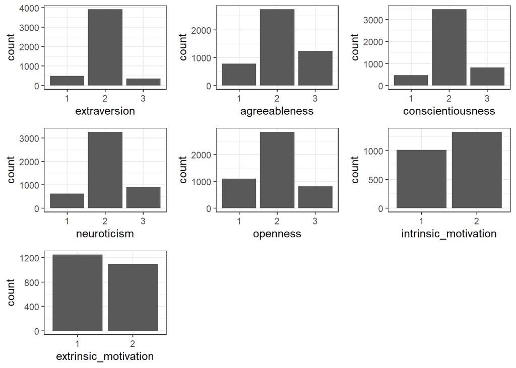

```r
dat_plot <- ggarrange(a, b, c, d, e, f, g,
                      ncol = 3, nrow = 3)
dat_plot
```

The variables shown above formed the input variables for further analyses.

### Data Processing

We computed the Latent-Class-Analysis following the guide by (Weller et al., 2020) using the software poLCA (Linzer & Lewis, 2011). The package handles missing data by excluding any manifest variables with missing observations from the calculation. The priors within the expectation-maximization algorithm are updated in using as many or as few manifest variables as are observed for each individual (Linzer & Lewis, 2011). This follows the assumption that in computing LCA specific handling of missing values is not necessary.

```r
f <- with(dat_lca, cbind(par_edu, par_ocu, mig_bac, typ_sch, paa_gpa,
                         ext_rnk, agr_rnk, con_rnk, neu_rnk,
                         ope_rnk, inm_di, exm_di) ~ 1)

set.seed(123)
lc1 <- poLCA(f, dat_lca, nclass = 1, na.rm = FALSE, nrep = 10, maxiter = 5000)
lc2 <- poLCA(f, dat_lca, nclass = 2, na.rm = FALSE, nrep = 10, maxiter = 5000)
lc3 <- poLCA(f, dat_lca, nclass = 3, na.rm = FALSE, nrep = 10, maxiter = 8000)
lc4 <- poLCA(f, dat_lca, nclass = 4, na.rm = FALSE, nrep = 10, maxiter = 5000)
lc5 <- poLCA(f, dat_lca, nclass = 5, na.rm = FALSE, nrep = 10, maxiter = 8000)
lc6 <- poLCA(f, dat_lca, nclass = 6, na.rm = FALSE, nrep = 10, maxiter = 5000)

# generate dataframe with fit-values
results <- data.frame(Modell = c("Modell 1"),
                      log_likelihood = lc1$llik,
                      df = lc1$resid.df,
                      BIC = lc1$bic,
                      ABIC = (-2 * lc1$llik) + ((log((lc1$N + 2) / 24)) * lc1$npar),
                      CAIC = (-2 * lc1$llik) + lc1$npar * (1 + log(lc1$N)),
                      likelihood_ratio = lc1$Gsq)

results$Modell <- as.integer(results$Modell)
results[1,1] <- c("Modell 1")
results[2,1] <- c("Modell 2")
results[3,1] <- c("Modell 3")
results[4,1] <- c("Modell 4")
results[5,1] <- c("Modell 5")
results[6,1] <- c("Modell 6")

results[2,2] <- lc2$llik
results[3,2] <- lc3$llik
results[4,2] <- lc4$llik
results[5,2] <- lc5$llik
results[6,2] <- lc6$llik

results[2,3] <- lc2$resid.df
results[3,3] <- lc3$resid.df
results[4,3] <- lc4$resid.df
results[5,3] <- lc5$resid.df
results[6,3] <- lc6$resid.df

results[2,4] <- lc2$bic
results[3,4] <- lc3$bic
results[4,4] <- lc4$bic
results[5,4] <- lc5$bic
results[6,4] <- lc6$bic

results[2,5] <- (-2*lc2$llik) + ((log((lc2$N + 2)/24)) * lc2$npar) #abic
results[3,5] <- (-2*lc3$llik) + ((log((lc3$N + 2)/24)) * lc3$npar)
results[4,5] <- (-2*lc4$llik) + ((log((lc4$N + 2)/24)) * lc4$npar)
results[5,5] <- (-2*lc5$llik) + ((log((lc5$N + 2)/24)) * lc5$npar)
results[6,5] <- (-2*lc6$llik) + ((log((lc6$N + 2)/24)) * lc6$npar)

results[2,6] <- (-2*lc2$llik) + lc2$npar * (1 + log(lc2$N)) #caic
results[3,6] <- (-2*lc3$llik) + lc3$npar * (1 + log(lc3$N))
results[4,6] <- (-2*lc4$llik) + lc4$npar * (1 + log(lc4$N))
results[5,6] <- (-2*lc5$llik) + lc5$npar * (1 + log(lc5$N))
results[6,6] <- (-2*lc6$llik) + lc6$npar * (1 + log(lc6$N))

results[2,7] <- lc2$Gsq
results[3,7] <- lc3$Gsq
results[4,7] <- lc4$Gsq
results[5,7] <- lc5$Gsq
results[6,7] <- lc6$Gsq

# add entropy
entropy <- function (p) sum(-p*log(p))

results$R2_entropy
results[1,8] <- c("-")

error_prior <- entropy(lc2$P) # class proportions model 2
error_post <- mean(apply(lc2$posterior,1, entropy),na.rm = TRUE)
results[2,8] <- round(((error_prior-error_post) / error_prior), 3)

error_prior <- entropy(lc3$P) # class proportions model 3
error_post <- mean(apply(lc3$posterior,1, entropy),na.rm = TRUE)
results[3,8] <- round(((error_prior-error_post) / error_prior), 3)

error_prior <- entropy(lc4$P) # class proportions model 4
error_post <- mean(apply(lc4$posterior,1, entropy),na.rm = TRUE)
results[4,8] <- round(((error_prior-error_post) / error_prior), 3)

error_prior <- entropy(lc5$P) # class proportions model 5
error_post <- mean(apply(lc5$posterior,1, entropy),na.rm = TRUE)
results[5,8] <- round(((error_prior-error_post) / error_prior), 3)

error_prior <- entropy(lc6$P) # class proportions model 6
error_post <- mean(apply(lc6$posterior,1, entropy),na.rm = TRUE)
results[6,8] <- round(((error_prior-error_post) / error_prior), 3)

colnames(results) <- c("Model","log-likelihood","resid.df","BIC","aBIC","cAIC",
                       "likelihood-ratio", "Entropy")

results <- round_df(results, digits = 2)
```

**Results of the Latent -Class-Analysis (Model Fit Parameters)**

[output not shown]

*Note.* resd.df = residual degrees of freedom, BIC = Bayesian Information Criterion, aBIC = adjusted BIC, cAIC = consistent Akaike Information Criterion.

Model fit was examined based on our theoretical understanding of dropout from teacher education and the BIC (Bayesian Information Criterion) as a statistical criterion, with lower BIC indicating better model fit (Nylund et al., 2007).

Additionally, we reviewed the following classification diagnostics criteria. We desired entropy above .80 and the lowest average latent class posterior probability to be between .80 and .90 (Weller et al., 2020).

We decided that the three-class solutions is to be preferred. It is the model with the lowest BIC and the highest entropy. Even if the latter and the lowest average latent class posterior probabilities are not as high as we desired, we interpret them as acceptable.

The average latent posterior probabilities are presented in a matrix with diagonals. It represents the average probability of a person being assigned to a class given the indicator variables used. Higher diagonal values are desirable. Off-diagonal elements in the posterior probability matrix contain probabilities of cases that belong in one class being assigned to another class (Bauer, 2021). The average latent class posterior probabilities of the three-class solution are displayed below:

```r
meanpostprob <- round(aggregate(x = lc3$posterior,
                                by = list(lc3$predclass),FUN = "mean") , 2)
meanpostprob
```

```
  Group.1   V1   V2   V3
1       1 0.71 0.04 0.26
2       2 0.05 0.89 0.06
3       3 0.15 0.01 0.83
```

### Final Class Solution

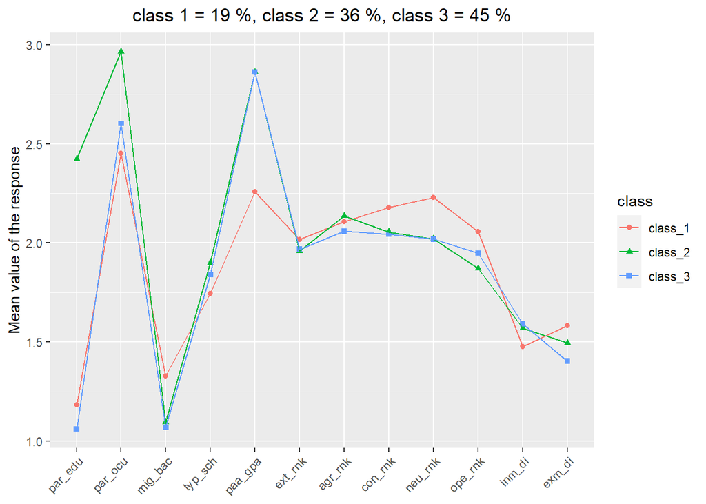

```r
best_model <- lc3
plot <-  profile_plot(data = dat_lca, num_var = 12, model = lc3, form = f)
print(plot +
        ggtitle("class 1 = 19 %, class 2 = 36 %, class 3 = 45 %"))
```

*Figure 1.* Latent Classes. par_edu = parental education (1, 2, 3), par_ocu = parental occupation (1, 2, 3), mig_bac = migration background (1, 2), typ_sch = type of school (1, 2), paa_gpa = prior academic achievment (1, 2, 3, 4), ext_rnk = extraversion (1, 2, 3), agr_rnk = agreeableness (1, 2, 3), con_rnk = conscientiousness (1, 2, 3), neu_rnk = neuroticism (1, 2, 3), ope_rnk = openness (1, 2, 3), inm_di = intrinsic motivation for choosing teacher education (1, 2), exm_di = extrinsic motivation (1, 2). Possible manifestations are displayed in brackets.

The classes can be described as follows:

**Class 1** compromised 19 % of the sample.

Regarding their personality traits, they were more likely highly extraverted, open and, contrary to what was assumed, showed the highest probability of being high in conscientiousness among all groups.

Regarding their motivation of choosing teacher education, members of this group described themselves most likely as high extrinsically motivated and low intrinsically motivated.

**Class 2** describes 36 % of the sample.

In contrast to class 1, members of class 2 are descried through the highest probability of both parents have attained tertiary education and are working under upper class regulations of employment. They most likely have no migration background, attained a Gymnasium and finished school with most likely good grades.

Describing their personality it can be said that they most likely fall in the medium categories of extraversion, agreeableness, conscientiousness, neuroticism and openness.

They describe their motivation for choosing teacher education more likely to be intrinsically motivated and are ambiguous regarding extrinsic motives showing roughly equal conditional probabilities for both categories.

The **third** class compromised 45 % of the sample.

Also, regarding there personality traits, members showed similar distribution patterns as members of class 2 did.

Regarding their motivation of choosing teacher education, members of this group described themselves most likely as high intrinsically motivated and low extrinsically motivated.

**Overall**, class 2 shows conditional response probabilities regarding socioeconomic, familiar and educational background, personality and motivation that overall indicate positive effects in regards to academic success.

While class 3 seems to be at-risk in terms of their socioeconomic and familiar background they tend to have advantageous educational prerequisites as well as a favorable motivational state.

Class 1 showed itself potentially unfavorable on most variables and might be interpreted as a group of students potentially at-risk for educational failure and dropout. It must be noted that their high probability of being high in conscientiousness is contradicting.

Statistical tests on which conditional response probabilities differ from each other have not yet been computed. The portrayal is purely descriptive.

## Further Considerations

In order to compute results on the other predictions, we would like to assign each case to a specific group based on their posterior class membership probabilities in order to use this as a manifest variable for further analyses. As this procedure is not uncontroversial and under suspicion of producing biased results (Bauer, 2021) we followed Sinha et al. (2020) and used a probability cut-off of ≥ 0.5 to assign class in order to address uncertainty.

```r
data6 <- data6 %>%
  dplyr::mutate(class = case_when(lc3$posterior[,1]  >= 0.5 &
                                    lc3$posterior[,2] < 0.5 &
                                    lc3$posterior[,3] < 0.5 ~ 1,
                                  lc3$posterior[,2]  >= 0.5 &
                                    lc3$posterior[,1] < 0.5 &
                                    lc3$posterior[,3] < 0.5 ~ 2,
                                  lc3$posterior[,3]  >= 0.5 &
                                    lc3$posterior[,1] < 0.5 &
                                    lc3$posterior[,2] < 0.5 ~ 3,
                                  TRUE ~ as.numeric(NA)))
data6$class <- as.factor(data6$class)
```

To further describe the classes in a broader context, graphs showing the distribution of type of intended teaching degree as well as gender per class are displayed below.

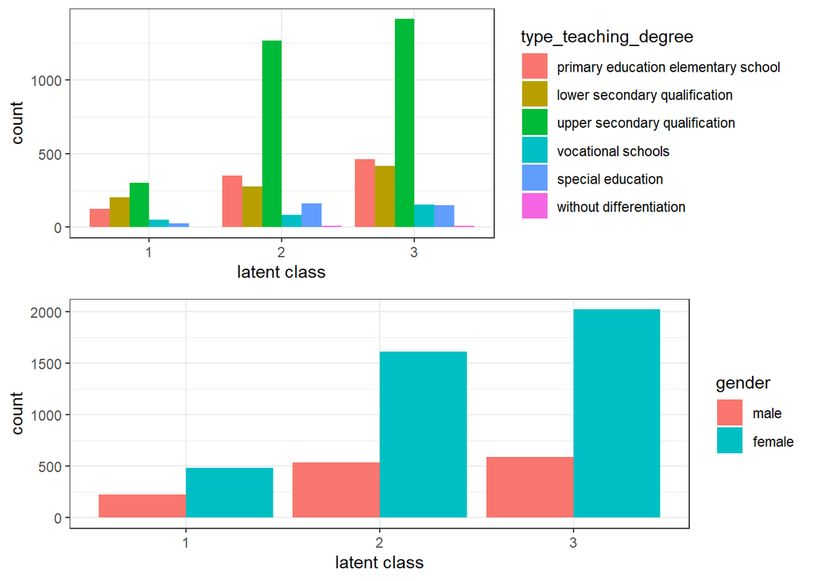

```r
data7 <- data6
data7$tg24202_g1 <- as.factor(data7$tg24202_g1)
data7$t700001 <- as.factor(data7$t700001)
levels(data7$tg24202_g1) <- c("primary education elementary school",
                              "lower secondary qualification",
                              "upper secondary qualification",
                              "vocational schools",
                              "special education",
                              "without differentiation")
data7$t700001 <- as.factor(data7$t700001)
levels(data7$t700001) <- c("male", "female")

data7 <- data7 %>%
  dplyr::filter(!is.na(tg24202_g1))  %>%
  dplyr::filter(!is.na(class)) %>%
  dplyr::rename(type_teaching_degree = tg24202_g1) %>%
  dplyr::rename(gender = t700001)

x <- ggplot(data7) + geom_bar(aes(x = class,
                                  fill = type_teaching_degree),
           position = "dodge") + labs(x = "latent class") + theme_bw()

y <- ggplot(data7) + geom_bar(aes(x = class,
                                  fill = gender),
           position = "dodge") + labs(x = "latent class") + theme_bw()

plot <- ggarrange(x, y, ncol = 1, nrow = 2)

plot
```

## Questions

- What do you think about the handling of the variables regarding personality and motivation for choosing teacher education?
- How would you rate the model selection?
- Is the graphical representation of the final model via the mean value of each response understandable, given the presence of formal categories?
- Do you know if Individual class assignment by modal posterior probability is (still) acceptable and a common practice?
- General considerations and thoughts are of course very welcome.

## References

Bauer, J. (2021). *A primer to latent profile and latent class analysis*. http://dx.doi.org/10.31234/osf.io/97uab

Blossfeld, H.-P., & Roßbach, H.-G. (Eds.). (2019). *Education as a lifelong process*. Springer Fachmedien Wiesbaden. https://doi.org/10.1007/978-3-658-23162-0

Heublein, U. (2014). Student Drop-out from German Higher Education Institutions. *European Journal of Education*, *49*(4), 497–513. https://doi.org/10.1111/ejed.12097

Isleib, S., Woisch, A., & Heublein, U. (2019). Ursachen des Studienabbruchs: Theoretische Basis und empirische Faktoren. *Zeitschrift für Erziehungswissenschaft*, *22*(5), 1047–1076. https://doi.org/10.1007/s11618-019-00908-x

Linzer, D. A., & Lewis, J. B. (2011). poLCA: An r package for polytomous variable latent class analysis. *Journal of Statistical Software*, *42*(10), 1–29. https://doi.org/10.18637/jss.v042.i10

Nylund, K. L., Asparouhov, T., & Muthén, B. O. (2007). Deciding on the Number of Classes in Latent Class Analysis and Growth Mixture Modeling: A Monte Carlo Simulation Study. *Structural Equation Modeling: A Multidisciplinary Journal*, *14*(4), 535–569. https://doi.org/10.1080/10705510701575396

Pohlmann, B., & Möller, J. (2010). Fragebogen zur erfassung der motivation für die wahl des lehramtsstudiums (FEMOLA)1. *Zeitschrift Fur Padagogische Psychologie - Z PADAGOG PSYCHOL*, *24*, 73–84. https://doi.org/10.1024/1010-0652.a000005

Rammstedt, B., & John, O. P. (2007). Measuring personality in one minute or less: A 10-item short version of the big five inventory in english and german. *Journal of Research in Personality*, *41*(1), 203–212. https://doi.org/https://doi.org/10.1016/j.jrp.2006.02.001

Schaeper, O., H. (2023). The german panel of teacher education students: Surveying (prospective) teachers from higher education into working life. *Journal of Open Psychology Data*, *11*(1), 1–28. https://doi.org/10.5334/jopd.76

Sinha, P., Calfee, C. S., & Delucchi, K. L. (2020). Practitioner’s Guide to Latent Class Analysis: Methodological Considerations and Common Pitfalls. *Critical Care Medicine*, *49*(1), e63–e79. https://doi.org/10.1097/ccm.0000000000004710

Tinto, V. (1975). Dropout from Higher Education: A Theoretical Synthesis of Recent Research. *Review of Educational Research*, *45*(1), 89–125. https://doi.org/10.3102/00346543045001089

Van Lissa, C. J., Garnier-Villarreal, M., & Anadria, D. (2023). Recommended Practices in Latent Class Analysis Using the Open-Source R-Package tidySEM. *Structural Equation Modeling: A Multidisciplinary Journal*, 1–9. https://doi.org/10.1080/10705511.2023.2250920

Weller, B. E., Bowen, N. K., & Faubert, S. J. (2020). Latent Class Analysis: A Guide to Best Practice. *Journal of Black Psychology*, *46*(4), 287–311. https://doi.org/10.1177/0095798420930932